[OHI British Columbia](http://www.ohibc.org/) | [OHI Science](http://ohi-science.org) | [Citation policy](https://github.com/OHI-Science/ohiprep/releases)

# OHIBC: Fishing licenses prep

Compiled on Tue Aug 13 09:10:00 2019 by ohara

```r
knitr::opts_chunk$set(fig.width = 6, fig.height = 4, fig.path = 'figs/',
                      echo = TRUE, message = FALSE, warning = FALSE)

# library(ggmap)
library(sf)

source('~/github/ohibc/src/R/common.R')  ### an OHIBC specific version of common.R

dir_git     <- '~/github/ohibc'
dir_spatial <- file.path(dir_git, 'prep/_spatial')  ### github: general buffer region shapefiles
dir_anx     <- file.path(dir_M, 'git-annex/bcprep')

### goal specific folders and info
goal     <- 'ao'
scenario <- 'v2017'
dir_goal <- file.path(dir_git, 'prep', goal, scenario)
dir_goal_anx <- file.path(dir_anx, goal, scenario)

### provenance tracking
# library(provRmd); prov_setup()

### set up the default BC projection to be BC Albers
p4s_bcalb <- c('bcalb' = '+init=epsg:3005')
```

# 1 Summary

This data is incorporated into the OHI British Columbia First Nations Resource Access and Opportunities (AO) goal.

# 2 Data Source

**Fishing licenses**

- **Reference**: From Karen Hunter, DFO
- **Downloaded**:

**Fishery Management Area boundaries**

- **Reference**: From Karen Hunter, DFO
- **Downloaded**: May 24, 2016
- **Description**: Pacific Fisheries Sub Management Areas
- **Native data resolution**: PFMSA
- **Format**: ESRI shapefile

**Census subdivision administrative boundaries**

- **Reference**: [Copyright © 2017, Province of British Columbia](http://www2.gov.bc.ca/gov/content/home/copyright)
- **Downloaded**: Aug 7, 2017 from:
  - http://www12.statcan.gc.ca/census-recensement/2011/geo/bound-limit/bound-limit-2016-eng.cfm (2016 census subdivisions)
- **Description**: Census subdivision administrative boundaries; choose “English”, “ArcGIS”, census subdivisions, cartographic boundary file option)
- **Native data resolution**: Census subdivision
- **Format**: ESRI shapefile

**2016 Census Total Population Results Census Subdivisions**

- **Reference**: [Statistics Canada, Prepared by: BC Stats, Ministry of Technology, Innovation and Citizens’ Services]
- **Downloaded**: Aug 7, 2017 from
  - http://www.bcstats.gov.bc.ca/StatisticsBySubject/Census/2016Census/PopulationHousing/CensusSubdivisions.aspx (2016)
- **Description**: Census subdivision populations for 2016
- **Native data resolution**: Census subdivision (note boundaries are different each year, use proper shapefile)
- **Format**: .csv

# 3 Methods

## 3.1 Read in data

Read in licenses files.

```r
lic_clean_file <- file.path(dir_goal_anx, 'int/licenses_clean.csv')

license_file <- file.path(dir_anx, '_raw_data/fishing_license',
                          'Pacific Region Commercial Fishing Licenses En.csv')
metadata_file <- file.path(dir_anx, '_raw_data/fishing_license',
                           'Commercial License Meta Data EN (1).csv')

metadata <- read_csv(metadata_file, skip = 54) %>%
  setNames(tolower(names(.)) %>% str_replace_all(' ', '_'))

if(!file.exists(lic_clean_file)) {

  licenses_raw <- read_csv(license_file, col_types = cols(.default = 'c')) %>%
    setNames(tolower(names(.)) %>% str_replace_all('[\\s()]+', '_'))


  for(tmp in names(licenses_raw)) {
    ### tmpname <- names(x)[1]
    licenses_raw[[tmp]] <- ifelse(is.na(licenses_raw[[tmp]]) &
                                    class(licenses_raw[[tmp]]) == 'character',
                                  '',
                                  licenses_raw[[tmp]])
  }

  lic_processed <- licenses_raw %>%
    mutate(licence_prefix = ifelse(licence_prefix == 'ATBRF', 'FATBR', licence_prefix)) %>%
    left_join(metadata, by = c('licence_prefix' = 'prefix')) %>%
    mutate(lic_holder = ifelse(licence_holder_type == 'VESSEL',
                               paste('vessel', licence_holder_vessel),
                               paste(licence_holder_first_name,
                                     licence_holder_midddle_name,
                                     licence_holder_last_name)),
           lic_oper   = ifelse(licence_holder_type == 'VESSEL',
                               paste('vessel', licence_operator_vessel),
                               paste(licence_operator_first_name,
                                     licence_operator_midddle_name,
                                     licence_operator_last_name)),
           vessel_own = ifelse(licence_holder_type == 'VESSEL',
                               paste(vessel_owner_first_name,
                                     vessel_owner_midddle_name,
                                     vessel_owner_last_name),
                               NA)) %>%
    mutate(year = licence_suffix,
           fn = str_detect(tolower(prefix_description), 'aborig|northern native|northernnative'),
           fn = ifelse(is.na(fn), FALSE, fn),
           area = ifelse(area == '', NA, area))

  area_fix_df <- read_csv(file.path(dir_goal, 'raw/license_na_lookup.csv'))
    ### This was assembled by Karen Hunter based on license prefixes
    ### with no area assigned - manually coded as "bc coast wide", "remove",
    ### or left as NA for unknown.

  lic_clean <- lic_processed %>%
    left_join(area_fix_df, by = c('licence_prefix' = 'prefix')) %>%
    mutate(area = ifelse(is.na(area), area_override, area)) %>%
    filter(is.na(area) | area != 'remove') %>%
      ### the is.na(area) keeps any undefined areas for now
    select(year,
           lic_prefix = licence_prefix,
           prefix_desc = prefix_description,
           lic_tab = licence_tab,
           fn, area,
           fishery_group, foreign_vessel,
           lic_hold_type = licence_holder_type,
           lic_hold_vessel = licence_holder_vessel,
           lic_oper_vessel = licence_operator_vessel,
           lic_holder, lic_oper, vessel_own,
           vessel_length_m = vessel_length_mr_)

  write_csv(lic_clean, lic_clean_file)
} else {
  message('File exists: ', lic_clean_file)
  # git_prov(c(license_file, metadata_file), 'input')
  # git_prov(lic_clean_file, 'output')
}
```

### 3.1.1 License areas

This link provides a look-up of different commercial management areas to PFMAs and PFMSAs. This might be useful for spatializing the licenses.

http://www.pac.dfo-mpo.gc.ca/fm-gp/licence-permis/areas-secteurs-eng.html

The table in this link has been saved as a .csv in the `ao/v2017/raw` folder.

## 3.2 First Nations license holders by fishery group

This bar chart shows the proportion of licenses allocated to First Nations for each fishery group. The indicated proportion is the *maximum* for that fishery group across all years.

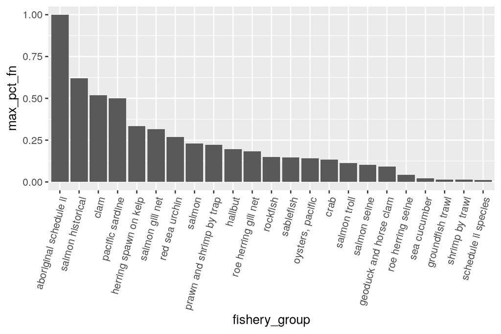

```r
lic_clean <- read_csv(lic_clean_file,
                      col_types = cols(.default = 'c')) %>%
  mutate(year = as.integer(year),
         fn   = as.logical(fn))

license_fn_yr <- lic_clean %>%
  select(year,
         prefix_desc,
         fn,
         lic_prefix,
         fishery_group) %>%
  mutate(fishery_group = tolower(fishery_group)) %>%
  group_by(year, fishery_group) %>%
  summarize(n_total = n(),
         n_fn = sum(fn),
         pct_fn = n_fn / n_total) %>%
  ungroup()

license_fn_yr <- license_fn_yr %>%
  group_by(fishery_group) %>%
  mutate(max_pct_fn = max(pct_fn, na.rm = TRUE)) %>%
  ungroup()

bar_by_gp <- license_fn_yr %>%
  select(max_pct_fn, fishery_group) %>%
  filter(max_pct_fn > 0) %>%
  distinct() %>%
  arrange(desc(max_pct_fn)) %>%
  mutate(fishery_group = factor(fishery_group, levels = unique(fishery_group))) %>%
  ggplot(aes(x = fishery_group, y = max_pct_fn)) +
    geom_bar(stat = 'identity') +
    theme(axis.text.x = element_text(angle = 75, hjust = 1))

print(bar_by_gp)
```

## 3.3 First Nations license ownership

This examines the total fishing license allocation to First Nations across all license types, fishery groups, and regions, by year.

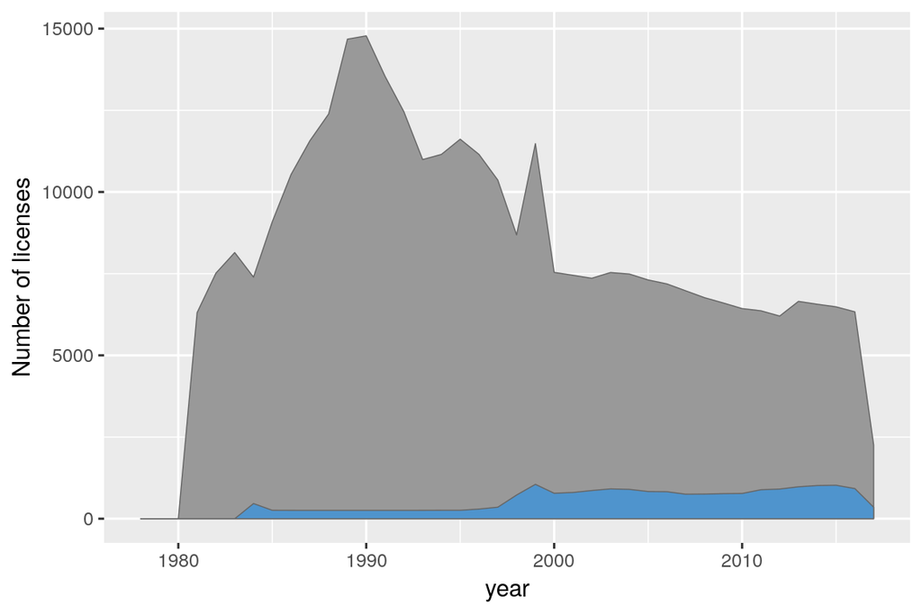

```r
lic_clean <- read_csv(lic_clean_file,
                      col_types = cols(.default = 'c')) %>%
  mutate(year = as.integer(year),
         fn   = as.logical(fn))

license_fn_yr1 <- lic_clean %>%
  select(year,
         prefix_desc,
         fn,
         lic_prefix,
         fishery_group) %>%
  mutate(fishery_group = tolower(fishery_group)) %>%
  group_by(year) %>%
  summarize(n_total = n(),
         n_fn = sum(fn),
         pct_fn = n_fn / n_total) %>%
  ungroup()

lic_total_plot <- ggplot(license_fn_yr1, aes(x = year, y = n_total)) +
  geom_area(fill = 'grey60', color = 'grey40', size = .25) +
  geom_area(aes(y = n_fn), fill = 'steelblue3', color = 'grey40', size = .25) +
  labs(y = 'Number of licenses')

lic_pct_plot <- ggplot(license_fn_yr1, aes(x = year, y = pct_fn)) +
  geom_line(color = 'steelblue3', size = .5) +
  labs(y = 'Percent FN licenses')

print(lic_total_plot)
```

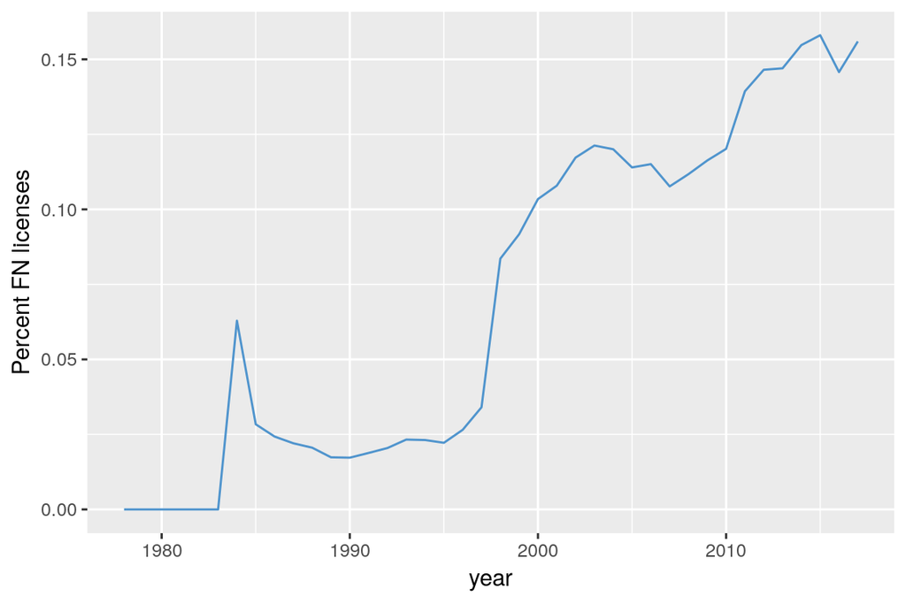

```r
print(lic_pct_plot)
```

## 3.4 Spatialize licenses

Much of this code was developed for the AO Closures prep script; since there are likely idiosyncracies within the data here compared to the closures data, the code has been copied and customized rather than functionalized.

### 3.4.1 Clean areas and subareas

Clean up area and subarea calls from the cleaned data. No need to keep the license info at this point; can rejoin later. Many of the descriptions are complex text such as “Area 12, Area 13, except SA 13-1 to 13-12, 13-15 to 13-17, Area 14 (except SA 14-5, 14-8, 14-15, Area 15 (except SA 15-5), Areas 16 to 29 (except SA 17-20, 23-6 and 29-5)” which must be parsed down to areas.

- Remove area-subarea notation and just keep the area level
- In many cases, areas are listed as, e.g., Areas 3 to 10.
  - Expand these to e.g. Areas 3 4 5 6 7 8 9 10.
  - These individual area numbers are then extracted as individual observations.
- bind with rows where no “to” clause existed
- join with lookup table of PFMA area to OHIBC rgn

```r
lic_area_all <- read_csv(lic_clean_file,
                         col_types = cols(.default = 'c')) %>%
  select(area, year) %>%
  group_by(area) %>%
  mutate(year   = as.integer(year),
         year_1 = min(year, na.rm = TRUE),
         year_n = max(year, na.rm = TRUE)) %>%
  ungroup() %>%
  select(-year) %>%
  distinct() %>%
  mutate(area = ifelse(is.na(area), 'no area designated', tolower(area)))

lic_area_lookup <- read_csv(file.path(dir_goal, 'raw/license_area_lookup.csv')) %>%
  mutate(lic_area = tolower(lic_area),
         desc     = tolower(desc))

# x <- lic_area_all %>%
#   filter(area %in% lic_area_lookup$lic_area) %>%
#   arrange(area)
# y <- lic_area_all %>%
#   filter(!area %in% lic_area_lookup$lic_area) %>%
#   arrange(area)
# z <- lic_area_lookup %>%
#   filter(!lic_area %in% lic_area_all$area) %>%
#   arrange(lic_area)
### All the remaining unmatched license areas (y) seem to have ended long ago,
### most before 2000, and only a couple as late as 2002 or 2003.
### Presumably these license areas are no longer valid, so don't show up
### in the license area designations.

### Because we are counting within regions rather than area-weighting, it is
### less important to worry about subareas.  Drop them for simplicity.  This
### also means not having to worry about "except" or "excludes"
lic_lookup_clean <- lic_area_lookup %>%
  select(lic_area, desc) %>%
  mutate(area_edit = desc,
         area_edit = str_replace_all(area_edit, '(?<=[0-9])[-—.](?=[0-9])', '~'), ### this line writes subareas as ##~##
         area_edit = str_replace_all(area_edit, '\\s+', ' '))

### step 2: expand 'to' for areas (e.g. areas 3 to 10).
### * Identify clauses, split into 'from'/'to'
### * create a vector of from:to and convert to string.
### * str_replace the clause with the expanded vector.
### * reassemble the entire closure list string
lic_lookup_to <- lic_lookup_clean %>%
  filter(str_detect(area_edit, '[0-9] to [0-9]')) %>%
  mutate(area_split = str_split(tolower(area_edit), ',|;|and')) %>% ### divide at comma or semicolon
  unnest(area_split) %>%
  mutate(to_clause = str_extract(area_split, '[0-9]*~?[0-9]+ to [0-9]+~?[0-9]*')) %>%
  separate(to_clause, into = c('from_num', 'to_num'), sep = '[^0-9]? to ', remove = FALSE) %>%
  rowwise() %>%
  ### build vector of Area numerals, skipping sub-areas
  mutate(to_vec = ifelse(!is.na(from_num) & !str_detect(from_num, '~') & !str_detect(to_num, '~'),
                         paste(as.integer(from_num):as.integer(to_num), collapse = ', '),
                         '')) %>%
  ### build vector of Sub-Area numerals, skipping areas
  mutate(tmp_area = ifelse(!is.na(from_num) & str_detect(from_num, '~') & str_detect(to_num, '~'),
                           str_extract(from_num, '[0-9]+(?=~)'), NA),
         to_vec_sub = ifelse(!is.na(from_num) & str_detect(from_num, '~') & str_detect(to_num, '~'),
                         paste(tmp_area, as.integer(str_extract(from_num, '(?<=~)[0-9]+')):as.integer(str_extract(to_num, '(?<=~)[0-9]+')), sep = '~', collapse = ', '),
                         '')) %>%
  ungroup() %>%
  mutate(to_vec = ifelse(to_vec == '', to_vec_sub, to_vec),
         area_split2 = ifelse(!is.na(to_clause),
                              str_replace(area_split, to_clause, to_vec),
                              area_split),
         area_split3 = str_replace_all(area_split2, '[^0-9~]+', ' '),
         area_split3 = str_trim(area_split3)) %>%
  select(-area_split, -area_split2, -to_clause, -from_num, -to_num, -to_vec) %>%
  distinct() %>%
  filter(!str_detect(area_split3, '[0-9]{4}')) %>% ### ditches four digit #s (i.e. years)
  group_by(lic_area) %>%
  summarize(desc      = first(desc),
            area_edit = paste(area_split3, collapse = ' ')) %>%
  ungroup()

lic_lookup_all <- lic_lookup_clean %>%
  filter(!lic_area %in% lic_lookup_to$lic_area) %>%
  mutate(area_edit = str_replace_all(area_edit, '[0-9]{4}', ''),
         area_edit = str_replace_all(area_edit, '[^0-9~]+', ' '),
         area_edit = str_trim(area_edit)) %>%
  bind_rows(lic_lookup_to) %>%
  mutate(pfma_area = str_split(area_edit, ' ')) %>%
  unnest(pfma_area) %>%
  separate(pfma_area, c('pfma', 'pfmsa'), '~') %>%
  mutate(pfma = as.integer(pfma),
         pfmsa = as.integer(pfmsa)) %>%
  select(-area_edit) %>%
  distinct()

### attach OHIBC regions by PFMA
pfma_lookup <- read_csv(file.path(dir_git, 'prep/fis/v2017/int/pfmsa_to_ohibc.csv')) %>%
  select(rgn_id, pfma_id, pfmsa_id) %>%
  filter(!is.na(pfma_id) & !is.na(rgn_id)) %>%
  distinct()

lic_lookup_rgn <- lic_lookup_all %>%
  filter(is.na(pfmsa)) %>%
  inner_join(pfma_lookup, by = c('pfma' = 'pfma_id')) %>%
  bind_rows(lic_lookup_all %>%
              filter(!is.na(pfmsa)) %>%
              inner_join(pfma_lookup, by = c('pfma' = 'pfma_id', 'pfmsa' = 'pfmsa_id'))) %>%
  select(-pfmsa_id, -pfmsa) %>%
  distinct()

write_csv(lic_lookup_rgn, file.path(dir_goal, 'int/lic_lookup_rgn.csv'))
```